# Top 1000 Technology Companies Data Analysis Project

This notebook performs data cleaning, analysis, and visualization on the dataset of the top 1000 technology companies.

# Project Brief

This project involves analyzing the dataset of the top 1000 technology companies based on their market capitalization. The goal is to clean the data, perform exploratory analysis, and generate insights that can be used for decision-making in the technology sector.

## Load and Explore the Dataset

```python
import pandas as pd
import matplotlib.pyplot as plt
import seaborn as sns

file_path = '/mnt/data/Top 1000 technology companies.csv'
tech_companies_data = pd.read_csv(file_path)
tech_companies_data.head()
```

|  | Ranking | Company | Market Cap | Stock | Country | Sector | Industry |
| --- | --- | --- | --- | --- | --- | --- | --- |
| 0 | 1 | Apple Inc. | $2.866 T | AAPL | United States | Technology | Consumer Electronics |
| 1 | 2 | Microsoft Corporation | $2.755 T | MSFT | United States | Technology | Software—Infrastructure |
| 2 | 3 | Nvidia Corporation | $1.186 T | NVDA | United States | Technology | Semiconductors |
| 3 | 4 | Broadcom Inc. | $495.95 B | AVGO | United States | Technology | Semiconductors |
| 4 | 5 | Taiwan Semiconductor Manufacturing Company Lim... | $487.64 B | 2330 | Taiwan | Technology | Semiconductors |

## Data Cleaning

```python
# Clean the 'Market Cap' column
tech_companies_data['Market Cap'] = tech_companies_data['Market Cap'].replace(
    {'\$': '', 'T': 'e12', 'B': 'e9', 'M': 'e6'}, regex=True
)
tech_companies_data['Market Cap'] = tech_companies_data['Market Cap'].str.replace(' ', '').astype(float)

# Sort the data by 'Ranking'
sorted_tech_companies_data = tech_companies_data.sort_values(by='Ranking')
sorted_tech_companies_data.head()
```

|  | Ranking | Company | Market Cap | Stock | Country | Sector | Industry |
| --- | --- | --- | --- | --- | --- | --- | --- |
| 0 | 1 | Apple Inc. | 2.866000e+12 | AAPL | United States | Technology | Consumer Electronics |
| 1 | 2 | Microsoft Corporation | 2.755000e+12 | MSFT | United States | Technology | Software—Infrastructure |
| 2 | 3 | Nvidia Corporation | 1.186000e+12 | NVDA | United States | Technology | Semiconductors |
| 3 | 4 | Broadcom Inc. | 4.959500e+11 | AVGO | United States | Technology | Semiconductors |
| 4 | 5 | Taiwan Semiconductor Manufacturing Company Lim... | 4.876400e+11 | 2330 | Taiwan | Technology | Semiconductors |

## Recommendations

Based on the analysis, the following recommendations are suggested:

1. **Investment Opportunities**: Investors may want to consider the semiconductor industry due to its significant representation among the top companies.
2. **Geographic Expansion**: Non-U.S. companies could explore opportunities to increase their presence in the U.S. market.
3. **Market Research**: Conduct further market research to understand the growth drivers behind the leading companies in the technology sector.

## Data Visualization

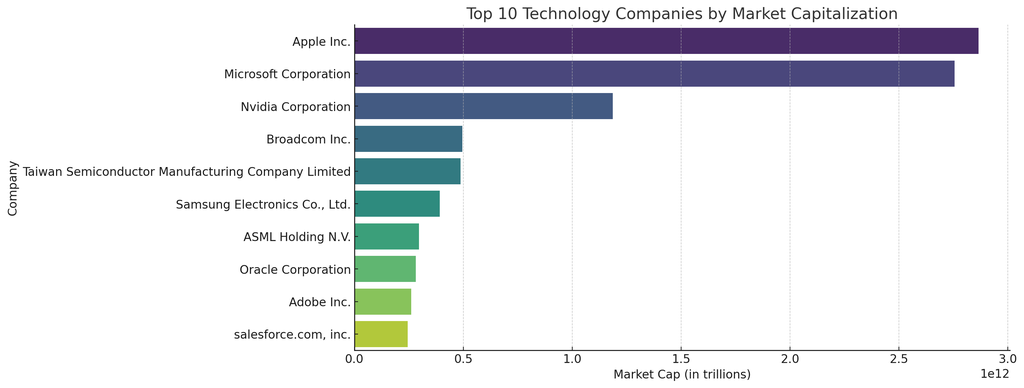

```python
# Visualizing the top 10 companies by market cap
top_10_companies = sorted_tech_companies_data.head(10)
plt.figure(figsize=(12, 6))
sns.barplot(x='Market Cap', y='Company', data=top_10_companies, palette='viridis')
plt.title('Top 10 Technology Companies by Market Capitalization')
plt.xlabel('Market Cap (in trillions)')
plt.show()
```

## Save Cleaned Data

Finally, save the cleaned dataset for further use.

```python
cleaned_excel_path = '/mnt/data/cleaned_tech_companies_data.xlsx'
sorted_tech_companies_data.to_excel(cleaned_excel_path, index=False)
print(f'Cleaned data saved to: {cleaned_excel_path}')
```

```
Cleaned data saved to: /mnt/data/cleaned_tech_companies_data.xlsx
```